#The libraries required for analysis are loaded in. Glimma and Limma are used for computation and analysis of differential expression. EdgeR is used to organize the data into a dataframe. Homo.sapiens is a key created by Bioconductor that allows the information of GeneID to be compared to other methods of naming.

```r
library(Glimma)
library(edgeR)
library(limma)
library(Homo.sapiens)
library(reticulate)
library(gsubfn)
```

#The working directory is set to the location where the files are stored.

```r
setwd("/Users/ramiyasivakumar/")
getwd()
```

```
## [1] "/Users/ramiyasivakumar"
```

#The files are stored into a collective location and they are read. The first 5 rows are printed as a result.

```r
files <- c("M1.tsv","M2.tsv","M3.tsv","M4.tsv","M5.tsv","M6.tsv","M7.tsv","M8.tsv","M9.tsv","M10.tsv","M11.tsv","M12.tsv","M13.tsv","M14.tsv","M15.tsv","M16.tsv","M17.tsv","M18.tsv","M19.tsv","M20.tsv","F1.tsv","F2.tsv","F3.tsv","F4.tsv","F5.tsv","F6.tsv","F7.tsv","F8.tsv","F9.tsv","F10.tsv","F11.tsv","F12.tsv","F13.tsv","F14.tsv","F15.tsv","F16.tsv","F17.tsv","F18.tsv","F19.tsv","F20.tsv")

read.delim(files[1],nrow=5,header=FALSE)
```

```
##                   V1   V2
## 1 ENSG00000000003.13 3255
## 2  ENSG00000000005.5    6
## 3 ENSG00000000419.11  896
## 4 ENSG00000000457.12  721
## 5 ENSG00000000460.15  310
```

#The contents of each tsv file is combined into one dataframe called as ‘x’. The data is grouped according to the parameter of Male vs. Female.

```r
x <- readDGE(files, columns=c(1,2))
```

```
## Meta tags detected: __no_feature, __ambiguous, __too_low_aQual, __not_aligned, __alignment_not_unique
```

```r
class(x)
```

```
## [1] "DGEList"
## attr(,"package")
## [1] "edgeR"
```

```r
dim(x)
```

```
## [1] 60487    40
```

```r
samplenames<-colnames(x)
sampleNames
```

[output not shown]

```r
colnames(x) <- samplenames
```

#The samples are grouped according to their gender.

```r
group <- c(rep("Male",20),rep("Female",20))
x$samples$group <- group
x$samples
```

```
##       files  group  lib.size norm.factors
## M1   M1.tsv   Male  90402348            1
## M2   M2.tsv   Male 109033035            1
## M3   M3.tsv   Male  84131736            1
## M4   M4.tsv   Male  93660040            1
## M5   M5.tsv   Male  69795193            1
## M6   M6.tsv   Male  61333943            1
## M7   M7.tsv   Male  98686635            1
## M8   M8.tsv   Male  77307145            1
## M9   M9.tsv   Male  85098944            1
## M10 M10.tsv   Male 110504657            1
## M11 M11.tsv   Male  65744038            1
## M12 M12.tsv   Male 101663554            1
## M13 M13.tsv   Male  70805909            1
## M14 M14.tsv   Male  87354771            1
## M15 M15.tsv   Male  61945154            1
## M16 M16.tsv   Male  67517888            1
## M17 M17.tsv   Male  87428671            1
## M18 M18.tsv   Male  87399851            1
## M19 M19.tsv   Male  97464289            1
## M20 M20.tsv   Male  79086526            1
## F1   F1.tsv Female  85735668            1
## F2   F2.tsv Female  50114369            1
## F3   F3.tsv Female  83288820            1
## F4   F4.tsv Female  81272098            1
## F5   F5.tsv Female 110490059            1
## F6   F6.tsv Female  52435233            1
## F7   F7.tsv Female  67923203            1
## F8   F8.tsv Female  76716985            1
## F9   F9.tsv Female  98472046            1
## F10 F10.tsv Female  84261259            1
## F11 F11.tsv Female  86007548            1
## F12 F12.tsv Female  63831905            1
## F13 F13.tsv Female  80250560            1
## F14 F14.tsv Female  94420239            1
## F15 F15.tsv Female 113461487            1
## F16 F16.tsv Female  99070050            1
## F17 F17.tsv Female 125130281            1
## F18 F18.tsv Female  68425821            1
## F19 F19.tsv Female  98520633            1
## F20 F20.tsv Female  79044318            1
```

#As the “Homo.sapiens” package doesn’t contain the ENSEMBL Gene ID in the format provided by the loaded data, the data must be converted using a substitution function. The digits following the decimal are replaced to look more similar to the key provided.

```r
library(Homo.sapiens)
library(gsubfn)
geneid <- rownames(x)
geneid <-gsub("\\.[0-9]*$","", geneid)
head(geneid)
```

```
## [1] "ENSG00000000005" "ENSG00000000419" "ENSG00000000457" "ENSG00000000460"
## [5] "ENSG00000000938" "ENSG00000000971"
```

#The dataframe genes is used to store the gene-level information corresponding to the rows of genes in our datasets. The information required for this data frame is retreived from the ‘Homo.sapiens’ library. The GeneIDs are associated with the symbol and the chromosome number of each gene.

```r
genes <- select(Homo.sapiens, keys=geneid, columns=c("SYMBOL", "TXCHROM"),
                keytype="ENSEMBL")
head(genes)
```

```
##           ENSEMBL   SYMBOL TXCHROM
## 1 ENSG00000000005     TNMD    chrX
## 2 ENSG00000000419     DPM1   chr20
## 3 ENSG00000000457    SCYL3    chr1
## 4 ENSG00000000460 C1orf112    chr1
## 5 ENSG00000000938      FGR    chr1
## 6 ENSG00000000971      CFH    chr1
```

```r
#doubt: are we supposed to have transformed data in this step?
genes <- genes[!duplicated(genes$ENSEMBL),]
x$genes <- genes
x
```

```
## An object of class "DGEList"
## $samples
##     files group  lib.size norm.factors
## M1 M1.tsv  Male  90402348            1
## M2 M2.tsv  Male 109033035            1
## M3 M3.tsv  Male  84131736            1
## M4 M4.tsv  Male  93660040            1
## M5 M5.tsv  Male  69795193            1
## 35 more rows ...
##
## $counts
##                     Samples
## Tags                  M1   M2  M3   M4  M5   M6   M7   M8   M9  M10 M11  M12
##   ENSG00000000005.5    6   11   4    3   8    2    5    2    2    4   2   36
##   ENSG00000000419.11 896 1325 785 1234 759 1011 2231 1763 1084 1198 666 1871
##   ENSG00000000457.12 721  990 584 1250 543  646  783  874  889  846 452  693
##   ENSG00000000460.15 310  215 209  601 215  233  453  516  342  333 209  546
##   ENSG00000000938.11 552  352 337  426 227  204 2237  128  894  511 577 1033
##                     Samples
## Tags                  M13  M14  M15 M16 M17  M18  M19  M20   F1  F2   F3   F4
##   ENSG00000000005.5     4    3    6   1   2    4    7    2    2   1    7    4
##   ENSG00000000419.11 1053 1298 2032 967 887 1086 1223 1023 1855 563 1093 1097
##   ENSG00000000457.12  480  517  761 589 698  776  887  701 1012 432  801 1007
##   ENSG00000000460.15  254  213  721 161 168  267  284  306  326 115  415  253
##   ENSG00000000938.11  336  244  192 432 562  879  373  322  316 134  410  225
##                     Samples
## Tags                   F5  F6  F7  F8   F9  F10  F11 F12  F13  F14  F15  F16
##   ENSG00000000005.5     8   0   1  11    3    6    4   6    6    2    3   20
##   ENSG00000000419.11 1286 598 783 886 1090 1121 2341 822 1090 1322 1430 1228
##   ENSG00000000457.12 1110 314 705 751  891  643 1067 469  632 1048 1364 1364
##   ENSG00000000460.15  248  89 204 241  408  135  710 110  350  288  394  294
##   ENSG00000000938.11  473 500 319 315  467  323   56 258  547  142  319  638
##                     Samples
## Tags                  F17  F18  F19  F20
##   ENSG00000000005.5     3    1    6   10
##   ENSG00000000419.11 1640 1398 1460 1080
##   ENSG00000000457.12 1124  735 1220  489
##   ENSG00000000460.15  287  226  422  196
##   ENSG00000000938.11  474  462  614  455
## 60482 more rows ...
##
## $genes
##           ENSEMBL   SYMBOL TXCHROM
## 1 ENSG00000000005     TNMD    chrX
## 2 ENSG00000000419     DPM1   chr20
## 3 ENSG00000000457    SCYL3    chr1
## 4 ENSG00000000460 C1orf112    chr1
## 5 ENSG00000000938      FGR    chr1
## 60482 more rows ...
```

```r
###### This part doesnt work now head(genes)
```

#The data is transformed from its raw form to more useable. The calculations of “cpm: counts per million” and “lcpm: log of counts per million” are carried out to do so.

```r
cpm <- cpm(x)
lcpm <- cpm(x, log=TRUE)
```

#For further calculations the data is processed using the calculations below.

```r
L <- mean(x$samples$lib.size) * 1e-6
M <- median(x$samples$lib.size) * 1e-6
c(L, M)
```

```
## [1] 84.63092 84.68010
```

```r
summary(lcpm)
```

```
##        M1                M2                M3                M4
##  Min.   :-5.4031   Min.   :-5.4031   Min.   :-5.4031   Min.   :-5.403
##  1st Qu.:-5.4031   1st Qu.:-5.4031   1st Qu.:-5.4031   1st Qu.:-5.403
##  Median :-4.4499   Median :-4.9300   Median :-4.8153   Median :-4.474
##  Mean   :-2.3497   Mean   :-2.3972   Mean   :-2.5008   Mean   :-2.259
##  3rd Qu.: 0.2517   3rd Qu.: 0.1571   3rd Qu.:-0.1854   3rd Qu.: 0.348
##  Max.   :17.7704   Max.   :17.4162   Max.   :18.1986   Max.   :17.407
##        M5               M6                M7                M8
##  Min.   :-5.403   Min.   :-5.4031   Min.   :-5.4031   Min.   :-5.4031
##  1st Qu.:-5.403   1st Qu.:-5.4031   1st Qu.:-5.4031   1st Qu.:-5.4031
##  Median :-4.719   Median :-4.6462   Median :-4.5097   Median :-4.7733
##  Mean   :-2.406   Mean   :-2.3070   Mean   :-2.3346   Mean   :-2.4770
##  3rd Qu.: 0.097   3rd Qu.: 0.3914   3rd Qu.: 0.2123   3rd Qu.:-0.2992
##  Max.   :17.543   Max.   :17.4521   Max.   :17.8663   Max.   :17.5038
##        M9               M10               M11               M12
##  Min.   :-5.4031   Min.   :-5.4031   Min.   :-5.4031   Min.   :-5.4031
##  1st Qu.:-5.4031   1st Qu.:-5.4031   1st Qu.:-5.4031   1st Qu.:-5.4031
##  Median :-4.8208   Median :-4.9354   Median :-4.6862   Median :-4.5293
##  Mean   :-2.3872   Mean   :-2.4176   Mean   :-2.3932   Mean   :-2.2789
##  3rd Qu.: 0.0969   3rd Qu.: 0.1558   3rd Qu.: 0.2006   3rd Qu.: 0.5063
##  Max.   :17.7657   Max.   :17.4272   Max.   :17.6767   Max.   :18.2335
##       M13                 M14                M15               M16
##  Min.   :-5.403113   Min.   :-5.40311   Min.   :-5.4031   Min.   :-5.40311
##  1st Qu.:-5.403113   1st Qu.:-5.40311   1st Qu.:-5.4031   1st Qu.:-5.40311
##  Median :-4.727183   Median :-4.83322   Median :-4.6520   Median :-4.70114
##  Mean   :-2.433611   Mean   :-2.47662   Mean   :-2.2036   Mean   :-2.45408
##  3rd Qu.:-0.002705   3rd Qu.: 0.01167   3rd Qu.: 0.4977   3rd Qu.:-0.01984
##  Max.   :18.218747   Max.   :17.91835   Max.   :17.5908   Max.   :17.35005
##       M17                M18               M19               M20
##  Min.   :-5.40311   Min.   :-5.4031   Min.   :-5.4031   Min.   :-5.4031
##  1st Qu.:-5.40311   1st Qu.:-5.4031   1st Qu.:-5.4031   1st Qu.:-5.4031
##  Median :-4.83362   Median :-4.8335   Median :-4.8829   Median :-4.3534
##  Mean   :-2.44863   Mean   :-2.3664   Mean   :-2.5496   Mean   :-2.3142
##  3rd Qu.:-0.03109   3rd Qu.: 0.2096   3rd Qu.:-0.3914   3rd Qu.: 0.1018
##  Max.   :17.43865   Max.   :17.5275   Max.   :17.3318   Max.   :17.7716
##        F1                F2                F3                F4
##  Min.   :-5.4031   Min.   :-5.4031   Min.   :-5.4031   Min.   :-5.4031
##  1st Qu.:-5.4031   1st Qu.:-5.4031   1st Qu.:-5.4031   1st Qu.:-5.4031
##  Median :-4.8244   Median :-5.4031   Median :-4.8104   Median :-4.7984
##  Mean   :-2.4472   Mean   :-2.5671   Mean   :-2.3159   Mean   :-2.3597
```

[output cut: 15 more lines]

```
##  Max.   :18.03859   Max.   :17.3878   Max.   :17.503   Max.   :17.5045
##       F13               F14               F15               F16
##  Min.   :-5.4031   Min.   :-5.4031   Min.   :-5.4031   Min.   :-5.4031
##  1st Qu.:-5.4031   1st Qu.:-5.4031   1st Qu.:-5.4031   1st Qu.:-5.4031
##  Median :-4.7921   Median :-4.4799   Median :-4.9458   Median :-4.5123
##  Mean   :-2.3920   Mean   :-2.3106   Mean   :-2.4592   Mean   :-2.3400
##  3rd Qu.: 0.1797   3rd Qu.: 0.2621   3rd Qu.:-0.1025   3rd Qu.: 0.2442
##  Max.   :17.3648   Max.   :17.8536   Max.   :17.8887   Max.   :17.5310
##       F17              F18               F19               F20
##  Min.   :-5.403   Min.   :-5.4031   Min.   :-5.4031   Min.   :-5.403
##  1st Qu.:-5.403   1st Qu.:-5.4031   1st Qu.:-5.4031   1st Qu.:-5.403
##  Median :-4.983   Median :-4.7085   Median :-4.5086   Median :-4.785
##  Mean   :-2.566   Mean   :-2.3525   Mean   :-2.3220   Mean   :-2.410
##  3rd Qu.:-0.383   3rd Qu.: 0.2003   3rd Qu.: 0.3123   3rd Qu.: 0.169
##  Max.   :17.730   Max.   :17.3971   Max.   :17.3107   Max.   :17.804
```

#Some genes are lowly expressed and do not contribute to the statistical analysis in a meaningful manner. To understand the ratio of these genes the following line is run:

```r
table(rowSums(x$counts==0)==9)
```

```
##
## FALSE  TRUE
## 60028   459
```

#edgeR provides an easy method to remove these lowly expressed genes.

```r
keep.exprs <- filterByExpr(x, group=group)
x <- x[keep.exprs,, keep.lib.sizes=FALSE]
dim(x)
```

```
## [1] 21828    40
```

#The filtered versus unfiltered data is presented in a graphical manner using the following lines of code.

```r
lcpm.cutoff <- log2(10/M + 2/L)
library(RColorBrewer)
nsamples <- ncol(x)
col <- brewer.pal(nsamples, "Paired")
```

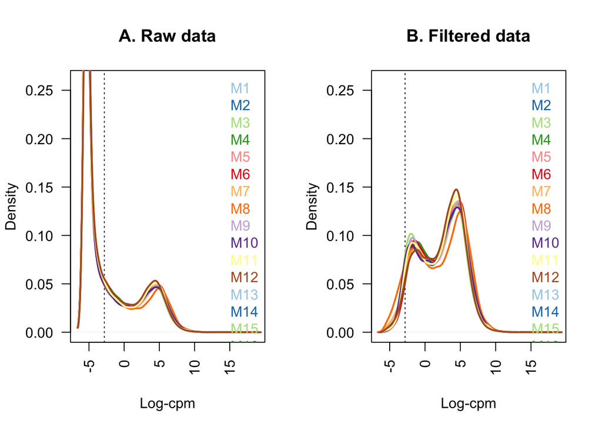

```r
par(mfrow=c(1,2))
plot(density(lcpm[,1]), col=col[1], lwd=2, ylim=c(0,0.26), las=2, main="", xlab="")
title(main="A. Raw data", xlab="Log-cpm")
abline(v=lcpm.cutoff, lty=3)
for (i in 2:nsamples){
den <- density(lcpm[,i])
lines(den$x, den$y, col=col[i], lwd=2)
}
legend("topright", samplenames, text.col=col, bty="n")
lcpm <- cpm(x, log=TRUE)
plot(density(lcpm[,1]), col=col[1], lwd=2, ylim=c(0,0.26), las=2, main="", xlab="")
title(main="B. Filtered data", xlab="Log-cpm")
abline(v=lcpm.cutoff, lty=3)
for (i in 2:nsamples){
den <- density(lcpm[,i])
lines(den$x, den$y, col=col[i], lwd=2)
}
legend("topright", samplenames, text.col=col, bty="n")
```

#For statistical analysis, the normalization of data is greatly beneficial. edgeR offers a function to do so. The resultant values are stored in a dataset called norm.factors.

```r
x <- calcNormFactors(x, method = "TMM")
x$samples$norm.factors
```

```
##  [1] 1.0020379 0.9998960 0.8121850 1.1252352 0.8883676 1.0978810 1.0584326
##  [8] 1.0987643 1.0103860 0.9371951 0.9580492 0.9787979 0.9896188 0.9160053
## [15] 1.2211237 0.9928968 0.9932883 1.0673652 1.0150355 0.9642935 1.1253449
## [22] 0.9006590 1.0959352 1.1224324 1.0613162 0.7728175 1.0390070 0.9444527
## [29] 0.9154738 1.0019347 1.0662230 0.8675735 1.0307900 0.9784302 0.9755478
## [36] 1.0434919 0.9196062 1.1387788 1.0881392 0.9543894
```

```r
x2 <- x
x2$samples$norm.factors <- 1
x2$counts[,1] <- ceiling(x2$counts[,1]*0.05)
x2$counts[,2] <- x2$counts[,2]*5
```

#The plot below shows data that is normalized versus unnormalized.

```
##  [1] 0.0565669 5.0250910 0.8501879 1.1795175 0.9544175 1.1582965 1.1149990
##  [8] 1.1192410 1.0411516 0.9568223 0.9851626 1.0061083 0.9947830 0.9145989
## [15] 1.2246003 1.0348213 1.0245462 1.1166866 0.9993739 1.0178357 1.1267933
## [22] 0.9473431 1.1531584 1.1245635 1.1189797 0.8177595 1.0787579 0.9937664
## [29] 0.9788179 0.9496282 1.0920720 0.8758330 1.0525218 1.0666622 1.0266223
## [36] 1.1356957 0.9457829 1.1825166 1.1207603 0.9689073
```

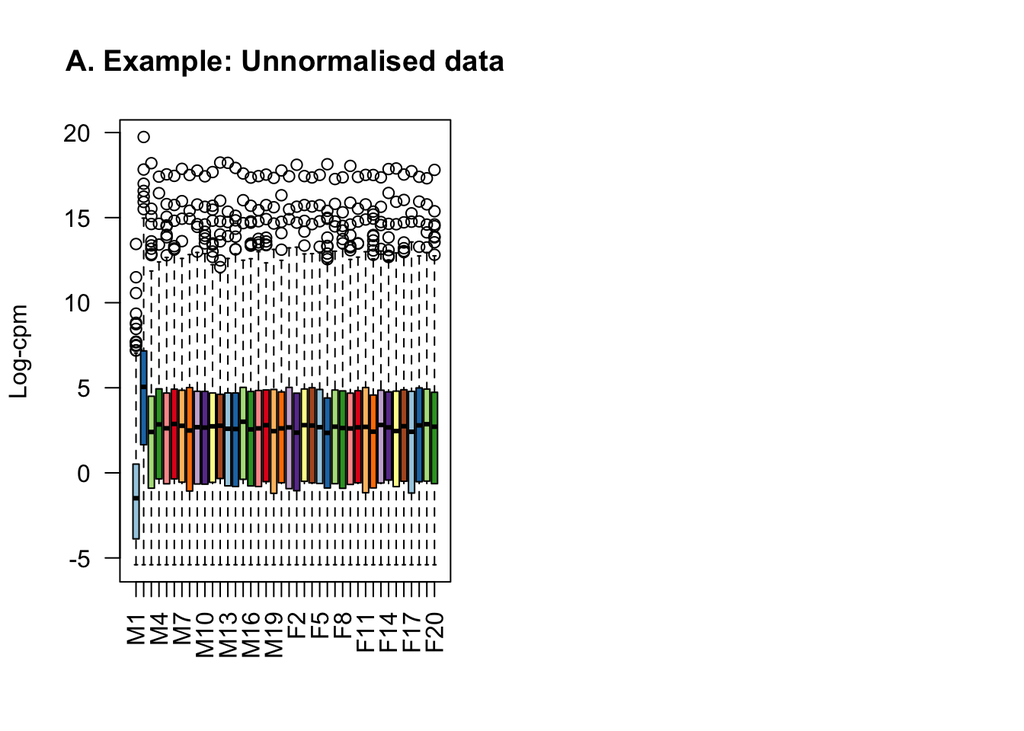

```r
par(mfrow=c(1,2))
lcpm <- cpm(x2, log=TRUE)
boxplot(lcpm, las=2, col=col, main="")
title(main="A. Example: Unnormalised data",ylab="Log-cpm")
x2 <- calcNormFactors(x2)
x2$samples$norm.factors
```

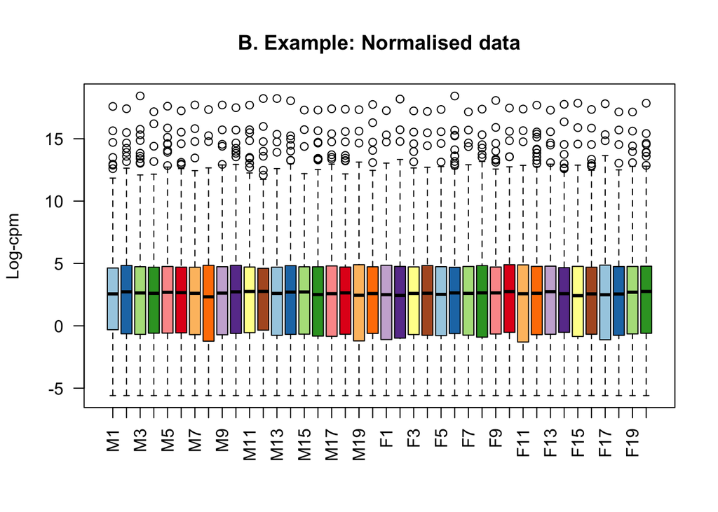

```r
lcpm <- cpm(x2, log=TRUE)
boxplot(lcpm, las=2, col=col, main="")
title(main="B. Example: Normalised data",ylab="Log-cpm")
```

#The MDS plot is an informative representation of the similarities and dissimilarities in a sample. The extent of the differences can give an idea of the expected results of the differential expression analysis. The plotMDS function of limma allows us to create the graph.

```r
library(limma)
library(Glimma)
lcpm <- cpm(x, log=TRUE)
par(mfrow=c(1,2))
group
```

```
##  [1] "Male"   "Male"   "Male"   "Male"   "Male"   "Male"   "Male"   "Male"
##  [9] "Male"   "Male"   "Male"   "Male"   "Male"   "Male"   "Male"   "Male"
## [17] "Male"   "Male"   "Male"   "Male"   "Female" "Female" "Female" "Female"
## [25] "Female" "Female" "Female" "Female" "Female" "Female" "Female" "Female"
## [33] "Female" "Female" "Female" "Female" "Female" "Female" "Female" "Female"
```

```r
levels(group) <-  brewer.pal(nlevels(group), "Set1")
```

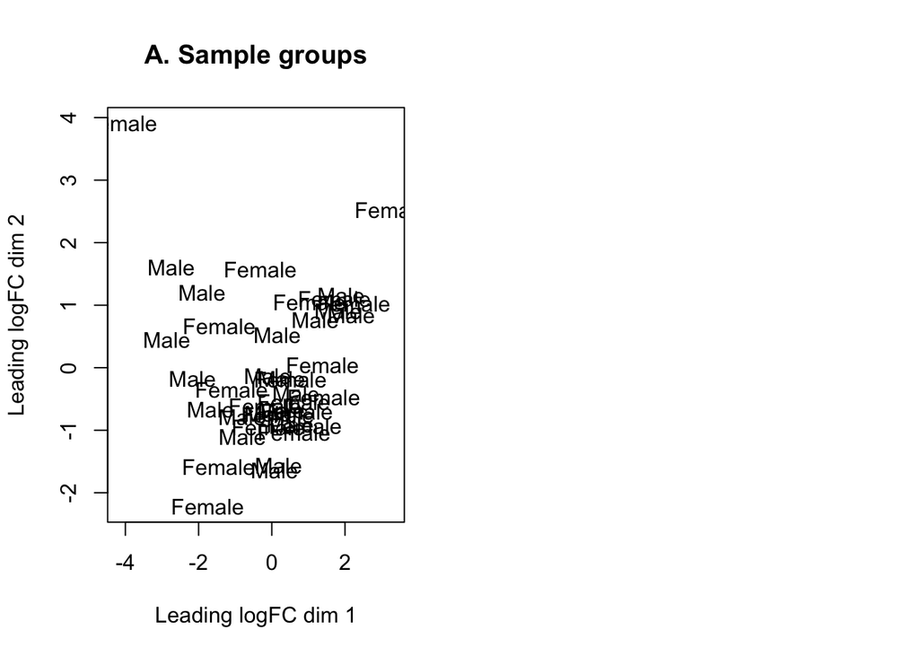

```r
col.group <- as.character(group)
col.group <- c("purple","orange")[group]
plotMDS(lcpm, labels=group, col=col.group)
title(main="A. Sample groups")
```

#An interactive version of this graph can be launched using glimma.

```r
glMDSPlot(lcpm,groups = group)
```

# We are now beginning the Differential expression analysis. The first step is to greate a design matrix with both the groups of data.

```r
design <- model.matrix(~0+group)
colnames(design) <- gsub("group", "", colnames(design))
design
```

```
##    Female Male
## 1       0    1
## 2       0    1
## 3       0    1
## 4       0    1
## 5       0    1
## 6       0    1
## 7       0    1
## 8       0    1
## 9       0    1
## 10      0    1
## 11      0    1
## 12      0    1
## 13      0    1
## 14      0    1
```

[output cut: 31 more lines]

#Contrasts for the two groups are created and stored in a matrix.

```r
contr.matrix <- makeContrasts(
   MaleVsFemale = Male-Female,
   levels = colnames(design))
contr.matrix
```

```
##         Contrasts
## Levels   MaleVsFemale
##   Female           -1
##   Male              1
```

#voom is a function within limma that allows the raw counts data to be transformed into the normalized data that accomadates the mean-variance relationship.

```
## An object of class "EList"
## $genes
##           ENSEMBL   SYMBOL TXCHROM
## 2 ENSG00000000419     DPM1   chr20
## 3 ENSG00000000457    SCYL3    chr1
## 4 ENSG00000000460 C1orf112    chr1
## 5 ENSG00000000938      FGR    chr1
## 6 ENSG00000000971      CFH    chr1
## 21823 more rows ...
##
## $targets
##     files group  lib.size norm.factors
## M1 M1.tsv  Male  90523268    1.0020379
## M2 M2.tsv  Male 108959424    0.9998960
## M3 M3.tsv  Male  68294240    0.8121850
## M4 M4.tsv  Male 105302785    1.1252352
## M5 M5.tsv  Male  61962717    0.8883676
## 35 more rows ...
##
## $E
##                     Samples
## Tags                       M1        M2       M3       M4       M5       M6
##   ENSG00000000419.11 3.307943 3.6046738 3.523775 3.551311 3.615578 3.910000
##   ENSG00000000457.12 2.994639 3.1843660 3.097367 3.569890 3.132808 3.264226
##   ENSG00000000460.15 1.778233 0.9838969 1.617114 2.514021 1.798216 1.794998
##   ENSG00000000938.11 2.609614 1.6938323 2.305052 2.018002 1.876394 1.603676
##   ENSG00000000971.14 4.413047 0.6203701 2.447405 1.718312 1.997956 2.476541
##                     Samples
## Tags                       M7        M8       M9      M10      M11      M12
##   ENSG00000000419.11 4.418523 4.3768081 3.657741 3.533488 3.404408 4.236609
##   ENSG00000000457.12 2.908515 3.3648968 3.371778 3.031840 2.845721 2.804382
##   ENSG00000000460.15 2.119684 2.6052068 1.994887 1.688017 1.734753 2.460707
##   ENSG00000000938.11 4.422397 0.5982068 3.379865 2.305064 3.197624 3.379952
##   ENSG00000000971.14 4.164705 0.9805995 2.761041 3.285899 2.409809 4.262583
##                     Samples
## Tags                      M13      M14      M15      M16       M17      M18
##   ENSG00000000419.11 3.911428 4.021254 4.751416 3.851993 3.3540200 3.542685
##   ENSG00000000457.12 2.778846 2.694038 3.335076 3.137224 3.0085330 3.058055
##   ENSG00000000460.15 1.861975 1.416716 3.257232 1.269266 0.9570215 1.520608
##   ENSG00000000938.11 2.264916 1.612314 1.351091 2.690432 2.6961260 3.237753
```

[output cut: 57 more lines]

```
## [1,] 2.462796 2.592473 2.798074 2.724483 2.841005 2.393915 2.763015 2.356389
## [2,] 2.056004 2.178338 2.387205 2.306590 2.431732 1.992676 2.349236 1.959108
## [3,] 1.234178 1.284051 1.375673 1.338914 1.397179 1.208594 1.358116 1.195162
## [4,] 1.356709 1.417685 1.529942 1.485769 1.556571 1.325748 1.508417 1.309933
## [5,] 1.608115 1.694427 1.854648 1.791262 1.892211 1.565871 1.824298 1.543559
## 21823 more rows ...
##
## $design
##   Female Male
## 1      0    1
## 2      0    1
## 3      0    1
## 4      0    1
## 5      0    1
## 35 more rows ...
```

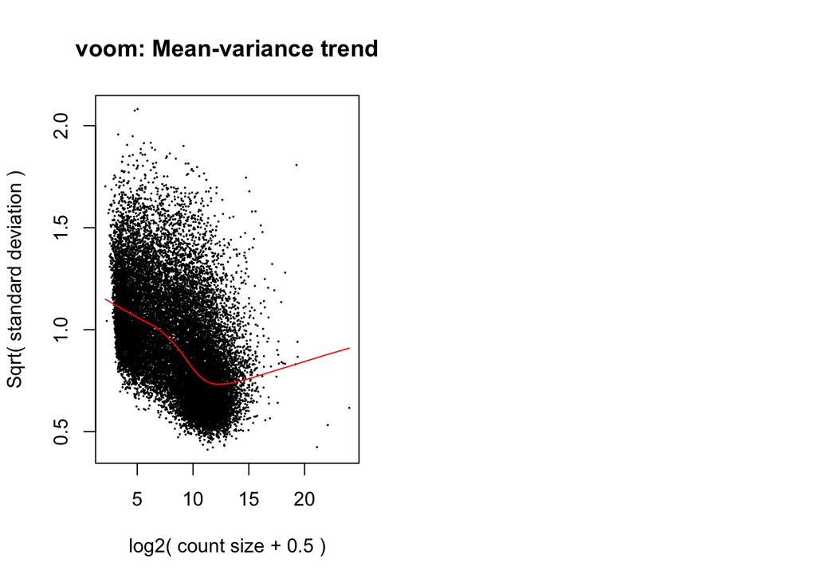

```r
par(mfrow=c(1,2))
v <- voom(x, design, plot=TRUE)
v
```

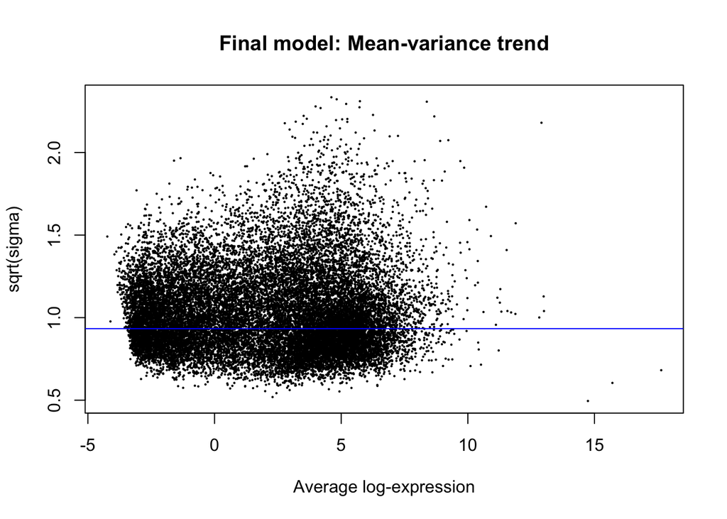

```r
vfit <- lmFit(v, design)
vfit <- contrasts.fit(vfit, contrasts=contr.matrix)
efit <- eBayes(vfit)
plotSA(efit, main="Final model: Mean-variance trend")
```

#To have a sneak peak at the differential expression levels, the following table can be created. (Up- up-regulated genes)

```r
summary(decideTests(efit))
```

```
##        MaleVsFemale
## Down              4
## NotSig        21807
## Up               17
```

#t-statistics allows for a more stringent definition of signigicance to be applied to the data.

```r
tfit <- treat(vfit, lfc=1)
dt <- decideTests(tfit)
summary(dt)
```

```
##        MaleVsFemale
## Down              1
## NotSig        21811
## Up               16
```

```r
de.common <- which(dt[,1]!=0)
length(de.common)
```

```
## [1] 17
```

```r
###
head(tfit$genes$SYMBOL[de.common], n=20)
```

```
##  [1] "KDM5D"  "DDX3Y"  "ZFY"    "PRKY"   "TTTY15" "RPS4Y1" "TXLNGY" "TMSB4Y"
##  [9] "NLGN4Y" "TTTY14" "UTY"    "EIF1AY" "XIST"   NA       NA       NA
## [17] NA
```

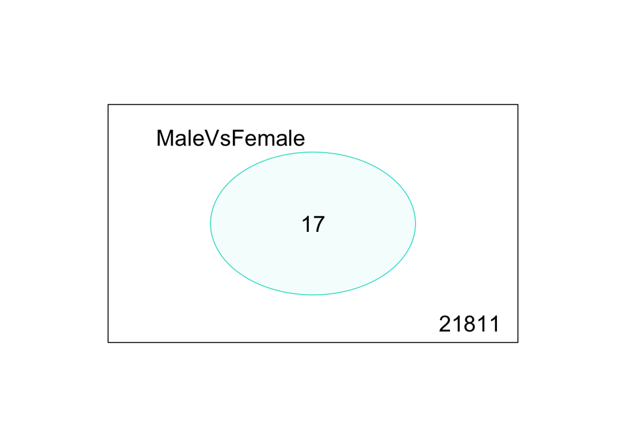

```r
vennDiagram(dt[,1], circle.col=c("turquoise", "salmon"))
```

```r
write.fit(tfit, dt, file="results.txt")
```

```r
###
Male.vs.Female <- topTreat(tfit, coef=1, n=Inf)
head(Male.vs.Female)
```

```
##                            ENSEMBL SYMBOL TXCHROM     logFC     AveExpr
## ENSG00000067646.10 ENSG00000067646    ZFY    chrY  9.321573 -1.54520439
## ENSG00000067048.15 ENSG00000067048  DDX3Y    chrY 10.445541  0.02312281
## ENSG00000131002.10 ENSG00000131002 TXLNGY    chrY 10.112160 -1.21540257
## ENSG00000233864.6  ENSG00000233864   <NA>    <NA>  9.346240 -1.78607446
## ENSG00000114374.11 ENSG00000114374 TTTY15    chrY  9.510812 -0.48857896
## ENSG00000012817.14 ENSG00000012817  KDM5D    chrY 10.443360 -0.04470537
##                           t      P.Value    adj.P.Val
## ENSG00000067646.10 19.27297 1.272780e-22 2.778224e-18
## ENSG00000067048.15 18.49637 5.898278e-22 6.437381e-18
## ENSG00000131002.10 17.78601 2.507780e-21 1.824661e-17
## ENSG00000233864.6  17.30470 6.858792e-21 3.488354e-17
## ENSG00000114374.11 17.23072 8.021839e-21 3.488354e-17
## ENSG00000012817.14 17.09390 1.073526e-20 3.488354e-17
```

#To summarise the genes, the log fold change is plot against the log counts per million using the plotMD function.

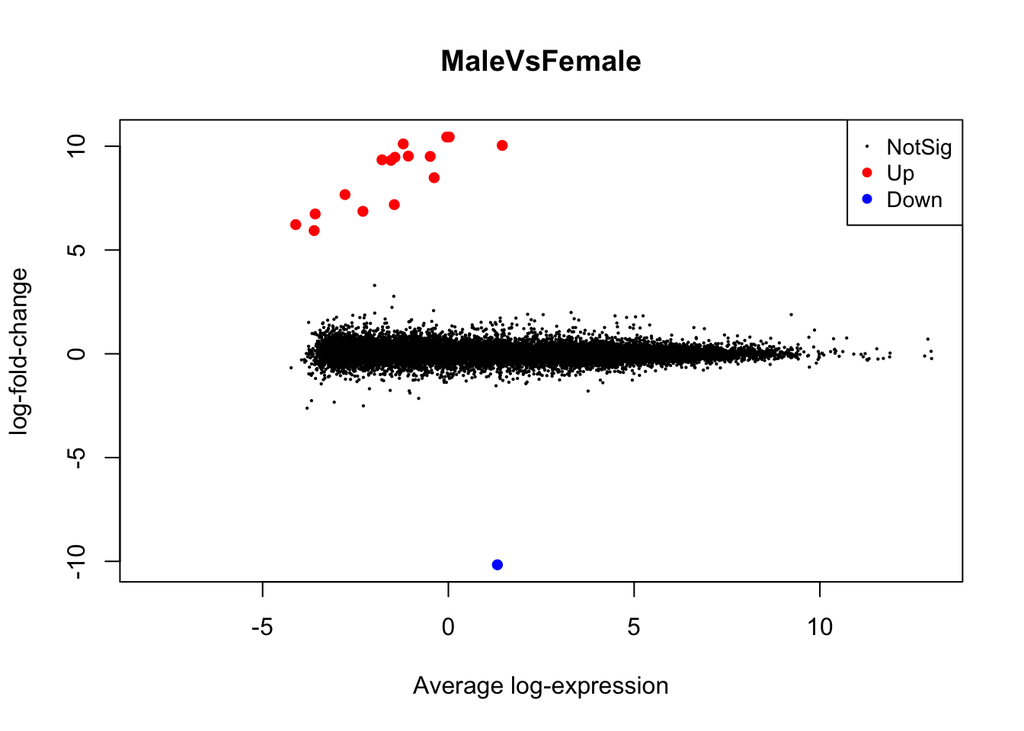

```r
plotMD(tfit, column=1, status=dt[,1], main=colnames(tfit)[1],
       xlim=c(-8,13))
```

#Glimma allows the same information to be presented interactively.

```r
glMDPlot(tfit, coef=1, status=dt, main=colnames(tfit)[1],
         side.main="ENSEMBL", counts=lcpm, groups=group, launch=TRUE)
```

```
library(gplots)
Male.vs.Female.topgenes <- Male.vs.Female$ENSEMBL[1:50]
i <- which(v$genes$ENSEMBL %in% Male.vs.Female.topgenes)
mycol <- colorpanel(1000,"blue","white","red")
par(mar=rep(2,4))
input <- as.matrix(t(lcpm))
par(cex.main=0.8,mar=c(1,1,1,1))
heatmap.plus(input, col=bluered(20),cexRow=1,cexCol=0.2, margins = c(20,13), main="HeatMap")
```

```
Male.vs.Female.topgenes <- Male.vs.Female$ENSEMBL[1:50]
i <- which(v$genes$ENSEMBL %in% Male.vs.Female.topgenes)
mycol <- colorpanel(1000,"blue","white","red")
par(cex.main=0.8,mar=c(1,1,1,1))
heatmap.2(lcpm[i,], scale="row",
   labRow=v$genes$SYMBOL[i], labCol=group,
   col=mycol, trace="none", density.info="none",
   margins=c(40,30),
   lhei=c(2,10), dendrogram="column")
```

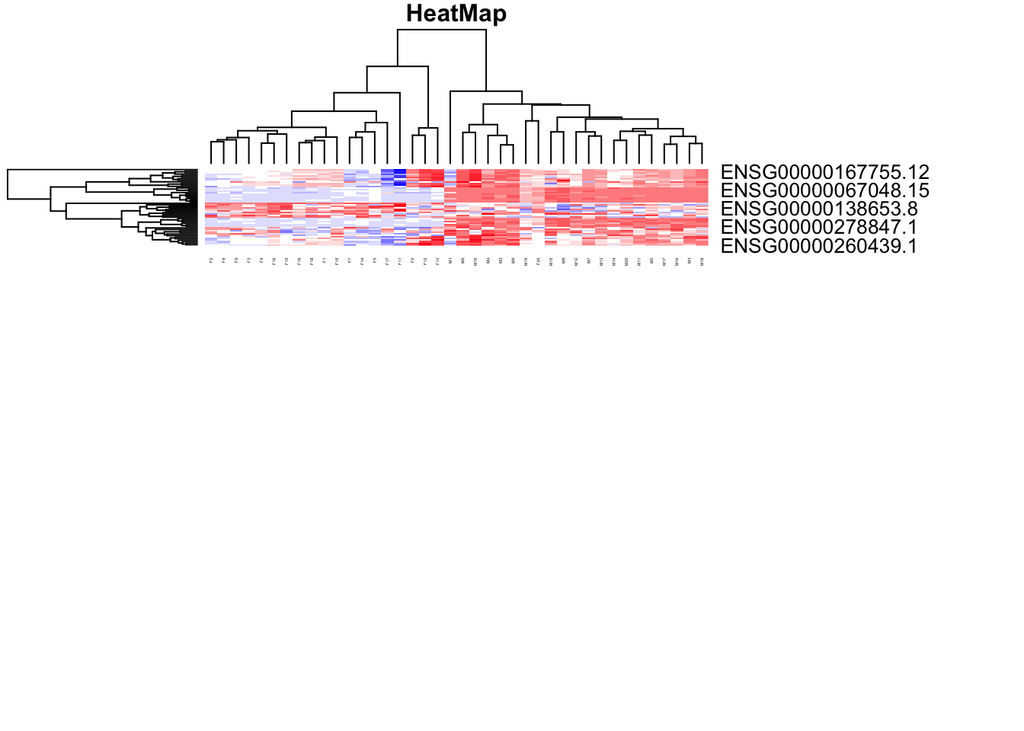

```r
library(gplots)
library(heatmap.plus)
Male.vs.Female.topgenes <- Male.vs.Female$ENSEMBL[1:50]
i <- which(v$genes$ENSEMBL %in% Male.vs.Female.topgenes)
mycol <- colorpanel(1000,"blue","white","red")
par(cex.main=0.8,mar=c(1,1,1,1))
heatmap.plus(lcpm[i,], col=bluered(20),cexRow=1,cexCol=0.2, margins = c(20,13), main="HeatMap")
```